# Question

A spinner was constructed:

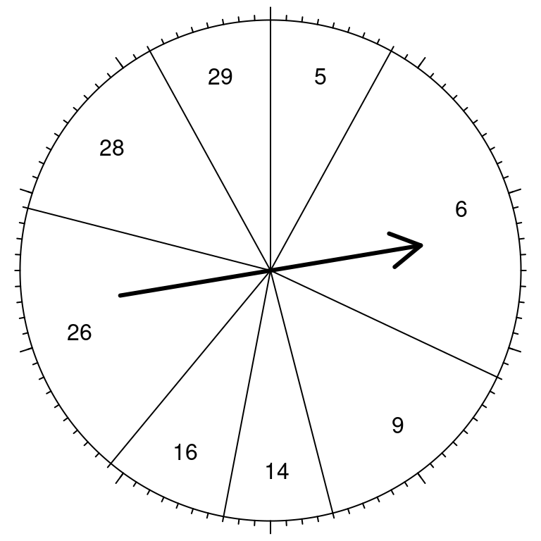

The spinner’s probability distribution is shown below.

| $x$ | $\mathbb{P}[x]$ |
| --- | --- |
| 5 | 0.08 |
| 6 | 0.24 |
| 9 | 0.14 |
| 14 | 0.07 |
| 16 | 0.08 |
| 26 | 0.18 |
| 28 | 0.13 |
| 29 | 0.08 |

It can also be downloaded as a csv.

## Answerlist

- What is the probability of spinning 6? In other words, what is $\mathbb{P}[X=6]$?
- What is the probability of spinning 14 or 29? In other words, what is $\mathbb{P}[X=14 ~\text{ or }~ X=29]$?
- If spinning twice, what is the probability of first spinning 14 and then spinning 29? In other words, what is $\mathbb{P}[X_1=14 ~\text{ and }~ X_2=29]$?
- What is the probability of spinning at least 16? In other words, what is $\mathbb{P}[X\ge 16]$?
- Determine the mean of the probability distribution by using $\mu = \sum x\cdot \mathbb{P}[x]$.
- Determine the standard deviation of the probability distribution by using $\sigma = \sqrt{\sum (x-\mu)^2 \cdot \mathbb{P}[x]}$.

# Solution

[video](https://vimeo.com/531915788)

Make a table (for parts mean and standard deviation).

| $x$ | $\mathbb{P}[x]$ | $x\cdot\mathbb{P}[x]$ | $x-\mu$ | $(x-\mu)^2$ | $(x-\mu)^2 \cdot \mathbb{P}[x]$ |
| --- | --- | --- | --- | --- | --- |
| 5 | 0.08 | 0.4 | -11 | 121 | 9.68 |
| 6 | 0.24 | 1.44 | -10 | 100 | 24 |
| 9 | 0.14 | 1.26 | -7 | 49 | 6.86 |
| 14 | 0.07 | 0.98 | -2 | 4 | 0.28 |
| 16 | 0.08 | 1.28 | 0 | 0 | 0 |
| 26 | 0.18 | 4.68 | 10 | 100 | 18 |
| 28 | 0.13 | 3.64 | 12 | 144 | 18.72 |
| 29 | 0.08 | 2.32 | 13 | 169 | 13.52 |
|  |  | $\sum x \cdot \mathbb{P}[x]=16.00$ |  |  | $\sigma^2=91.06$ |
|  |  | $\mu = 16.00$ |  |  | $\sigma=9.54$ |

## Answerlist

- 0.24
- $0.07 + 0.08$ = **0.15**
- $0.07 \times 0.08$ = **0.0056**
- 0.47
- $\mu = 16$
- $\sigma = 9.5425364$

# Meta-information

extype: cloze exsolution: 0.24|0.15|0.0056|0.47|16|9.5425364| exclozetype: num|num|num|num|num|num exname: probdist extol: 0.01 exextra[numwidth,logical]: TRUE